# Función gamma

R

1/3/2022

# Lab2

En esta asignatura entrenaremos *cosas* de matemáticas y sus amigos.

## La función Gamma

La función Gamma $\Gamma$ tiene diversas definiciones en la matemática. La definición que utilizaremos es:

$$\Gamma(z)= \int_0^{\infty} x^{z-1} \cdot e^{-x}dx, \mbox{ donde } z\in \mathbb{R}.$$

Resolvamos esta integral en el caso $\Gamma(z+1)$ con $z\in \mathbb{R}$. Recordemos que la fórmula integración por partes en este caso es:

$$\int_{0}^{\infty} u \cdot d v =\left[u\cdot v \right]_0^\infty-\int_0^{\infty} v \cdot du.$$

Apliquemos el método de integración por partes a la función $\Gamma$

$$\begin{eqnarray}
\Gamma(z+1) &=& \int_0^{\infty} x^{z} \cdot e^{-x}dx=
\left|
\begin{matrix} u=x^{z} & dv= e^{-x}\cdot dx
\\ du= z \cdot x^(z+1) & v=-e^{-x}
\end{matrix}
\right|=\\
&& \left[-x^z\cdot e^{-x}\right]_0^\infty
-\int_0^{\infty} z\cdot x^{z-1} \cdot \left(-e^{-x}\right)\cdot dx=\\
&&
\lim_{x\to\infty}\left(-x^z\cdot e^{-x}\right)
+
z\cdot \int_0^{\infty} x^{z-1} \cdot e^{-x}\cdot dx.
\end{eqnarray}$$

como

$$\lim_{x\to\infty}\left(-x^z\cdot e^{-x}\right)=0$$

tenemos que

$$\Gamma(z+1)=
z\cdot \int_0^{\infty} x^{z-1} \cdot e^{-x}\cdot dx.$$

Por lo que hemos encontrado una fórmula recurrente, en al que si queremos saber $\Gamma(z+1)$ tenemos que saber que vale $\Gamma(z)$ y utilizar la fórmula anterior.

## Las fórmulas recursivas

La fórmulas recursivas son las que dependen de un valor anterior al que se calcula. La más popular es el factorial

La definición de factorial de un un número natural $n\in\mathbb{N}$, e ¡¡obviamente!!! recursiva

$$\begin{align*}
\verb+factorial += n!: &\mathbb{N}& \longrightarrow &\mathbb{N}\\
& n &\longrightarrow & n\cdot (n-1)\cdot (n-2) \ldots \cdot 3\cdot 2\cdot 1.
\end{align*}$$

Se define con estas reglas:

1. `factorial(0)`=$0!=1$.
2. `factorial(n+1)=`$(n+1)!=(n+1)*factorial(n).$

En la notación matemática, como ya sabéis el factorial se representa con el símbolo de exclamación/admiración; así

1. `factorial(0)`:= $0!=1$.
2. `factorial(n+1)`:= $(n+1)!=(n+1)\cdot n!$.

Así tenemos que

- $0!=1.$
- $1!=1.$
- $2!= 2\cdot 1= 2.$
- $3!=3\cdot 2\cdot 1= 6.$
- $4!=4\cdot 3\cdot 2\cdot 1 =24.$
- $\ldots \ldots$
- $n!= n\cdot (n-1) \cdot (n-2) \cdots 3\cdot 2\cdot 1.$
- $(n+1)!= (n+1)\cdot n!= (n+1)\cdot n\cdot (n-1) \cdot (n-2) \cdots 3\cdot 2\cdot 1.$

# Gráfica fuhcion gamma en los reales

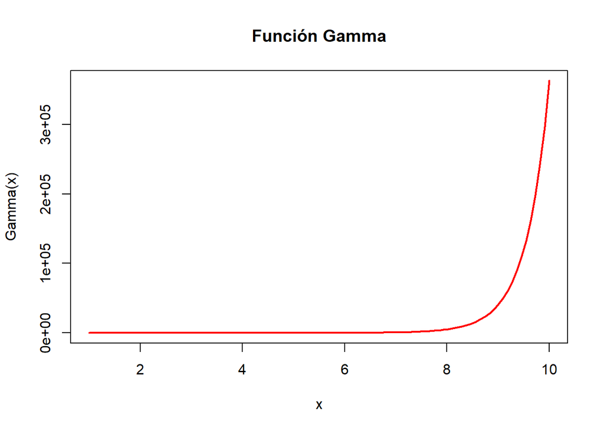

```r
curve(gamma(x),xlim=c(1,10),col="red",ylab="Gamma(x)",lwd=2,frame.plot=TRUE,main="Función Gamma")
```